# NOAA Storm Database Analysis

Michael Harrison

February 22, 2017

## Introduction

Storms and other severe weather events can cause both public health and economic problems for communities and municipalities. Many severe events can result in fatalities, injuries, and property damage, and preventing such outcomes to the extent possible is a key concern.

This project involves exploring the U.S. National Oceanic and Atmospheric Administration’s (NOAA) storm database. This database tracks characteristics of major storms and weather events in the United States, including when and where they occur, as well as estimates of any fatalities, injuries, and property damage.

Your data analysis must address the following questions:

1. Across the United States, which types of events (as indicated in the 𝙴𝚅𝚃𝚈𝙿𝙴 variable) are most harmful with respect to population health?
2. Across the United States, which types of events have the greatest economic consequences?

## Data Processing

### Cleaning

Data cleaning and organization will depend upon the following packages: data.table, dplyr, lubridate, and ggplot2(which is loaded later in the analysis to avoid masking issues with dplyr). Data from csv file read in using fread function of the data.table package for speed. All column names are set to lower case for ease in scripting; state columns renamed for clarity. Dates are transformed using the lubridate package function to set column to unambiguous date format. Data is then subset by date, starting on the first of January 1996, as NOAA began recording all event types.

```r
knitr::opts_chunk$set(error = TRUE)
library(data.table); library(dplyr);
library(lubridate);
options(scipen = 999)

stormdt_raw <- fread("StormData.csv")
stormdt <- stormdt_raw

colnames(stormdt) <- tolower(colnames(stormdt))
colnames(stormdt)[1] <- "fips"
colnames(stormdt)[7] <- "state"
```

```r
#change date formats
stormdt$bgn_date <- mdy_hms(stormdt$bgn_date)
stormdt$end_date <- mdy_hms(stormdt$end_date)
stormdt <- stormdt[bgn_date >= "1996-01-01"]
stormdt$bgn_datetime <- as.POSIXct(paste(stormdt$bgn_date, stormdt$bgn_time),
                                   format = "%Y-%m-%d %H:%M:%S")
stormdt$end_datetime <- as.POSIXct(paste(stormdt$end_date, stormdt$end_time),
                                   format = "%Y-%m-%d %H:%M:%S")
```

The following script takes the factor of property and crop damage and applies it to the damage standardize the value.

```r
factordmg <- function(DT){
        DT[propdmgexp == "H" | propdmgexp == "h", propdmg := propdmg * 100]
        DT[propdmgexp == "K" | propdmgexp == "k", propdmg := propdmg * 1000]
        DT[propdmgexp == "M" | propdmgexp == "m", propdmg := propdmg * 1E6]
        DT[propdmgexp == "B" | propdmgexp == "b", propdmg := propdmg * 1E9]
        for(i in 1:9){stormdt[propdmgexp == i, propdmg := propdmg * 10^i]}

        DT[cropdmgexp == "H" | cropdmgexp == "h", cropdmg := cropdmg * 100]
        DT[cropdmgexp == "K" | cropdmgexp == "k", cropdmg := cropdmg * 1000]
        DT[cropdmgexp == "M" | cropdmgexp == "m", cropdmg := cropdmg * 1E6]
        DT[cropdmgexp == 0, cropdmg := cropdmg * 10^0]
        DT[cropdmgexp == 2, cropdmg := cropdmg * 10^2]
}

stormdt <- factordmg(stormdt)
```

```r
stormdt <- stormdt %>%
        select(fips, state, county, countyname, evtype,
               time_zone, bgn_datetime, end_datetime, bgn_date, end_date,
               length, width, f, mag,
               fatalities, injuries, propdmg, cropdmg) %>%
        filter(fatalities > 0 | injuries > 0 | propdmg > 0 | cropdmg > 0)
```

```r
monthly_cpi <-
        read.table("https://research.stlouisfed.org/fred2/data/CPIAUCSL.csv",
                   header = TRUE, sep = ",")
colnames(monthly_cpi) <- tolower(colnames(monthly_cpi))
monthly_cpi$cpi_year <- year(monthly_cpi$date)

yearly_cpi <- monthly_cpi %>%
        group_by(cpi_year) %>%
        summarise(cpi = mean(value)) %>%
                mutate(adjustment =
                              yearly_cpi$cpi /
                              yearly_cpi$cpi[yearly_cpi$cpi_year ==2011])
```

```
## Error in eval(expr, envir, enclos): object 'yearly_cpi' not found
```

```r
stormdt$adjyear = year(stormdt$bgn_datetime)
stormdt$adjustment <- yearly_cpi$adjustment[match(stormdt$adjyear,
                                                   yearly_cpi$cpi_year)]
```

```
## Error in eval(expr, envir, enclos): object 'yearly_cpi' not found
```

```r
stormdt$adjpropdmg <- stormdt$propdmg / stormdt$adjustment
```

```
## Error in `$<-.data.frame`(`*tmp*`, "adjpropdmg", value = numeric(0)): replacement has 0 rows, data has 201313
```

```r
stormdt$adjcropdmg <- stormdt$cropdmg / stormdt$adjustment
```

```
## Error in `$<-.data.frame`(`*tmp*`, "adjcropdmg", value = numeric(0)): replacement has 0 rows, data has 201313
```

The data is reshaped to eliminate column variables unneeded for the purposes of the analysis using the select function of dplyr. The data is then filtered to remove records where fatalities, injuries, property damage, or crop damage amounted to zero.

Examining the unique values in the evtype variable returns nearly 1000 types of events, though has a set list of 48 event types for recording purposes. A variety of non-standard event types recorded and typo make up wide range of event types. The values stored in the evtype column were corrected to fit the standard 48 through cross referencing the NOAA storm database analysis handbook.

```r
stormdt$evtype <- tolower(stormdt$evtype)
stormdt$evtype <- trimws(stormdt$evtype, which = "both")
stormdt$evtype <- gsub("  ", " ", stormdt$evtype)
stormdt$evtype <- gsub("^tstm wind.*", "thunderstorm wind", stormdt$evtype)
stormdt$evtype <- gsub("^thunderstorm.*", "thunderstorm wind",
                       stormdt$evtype)
stormdt$evtype <- gsub("^hurricane.*", "hurricane(typhoon)",
                       stormdt$evtype)
stormdt$evtype <- gsub("^typhoon.*", "hurricane(typhoon)", stormdt$evtype)
stormdt$evtype <- gsub("^high wind.*", "high wind", stormdt$evtype)
stormdt$evtype <- gsub("^gust.*", "marine high wind", stormdt$evtype)
stormdt$evtype <- gsub("^non.*", "high wind", stormdt$evtype)
stormdt$evtype <- gsub(".*fire.*", "wildfire", stormdt$evtype)
stormdt$evtype <- gsub(".*surf.*", "high surf", stormdt$evtype)
stormdt$evtype <- gsub(".*astronomical high tide.*", "high surf",
                       stormdt$evtype)
stormdt$evtype <- gsub(".*coastal flooding.*", "coastal flood",
                       stormdt$evtype)
stormdt$evtype <- gsub("gradient wind", "tropcial depression",
                       stormdt$evtype)
stormdt$evtype <- gsub("landspout", "dust devil", stormdt$evtype)
stormdt$evtype <- gsub("lake effect snow", "lake-effect snow",
                       stormdt$evtype)
stormdt$evtype <- gsub("tropcial depression", "tropical depression",
                       stormdt$evtype)
stormdt$evtype <- gsub("marine tstm wind", "marine thunderstorm wind",
                       stormdt$evtype)
stormdt$evtype <- gsub("glaze", "freezing fog", stormdt$evtype)
stormdt$evtype <- gsub("^tropical storm wind.*", "tropical storm",
                       stormdt$evtype)
stormdt$evtype <- gsub(".*rain.*", "heavy rain", stormdt$evtype)
stormdt$evtype <- gsub(".*microburst.*", "thunderstorm wind",
                       stormdt$evtype)
stormdt$evtype <- gsub(".*whirlwind.*", "thunderstorm wind",
                       stormdt$evtype)
stormdt$evtype <- gsub(".*downburst.*", "thunderstorm wind",
                       stormdt$evtype)
stormdt$evtype <- gsub(".*small hail.*", "hail", stormdt$evtype)
stormdt$evtype <- gsub(".*blowing dust.*", "dust storm", stormdt$evtype)
stormdt$evtype <- gsub(".*fog.*", "dense fog", stormdt$evtype)
stormdt$evtype <- gsub(".*coastalstorm.*", "tropical storm",
                       stormdt$evtype)
stormdt$evtype <- gsub(".*coastal storm.*", "tropical storm",
                       stormdt$evtype)
stormdt$evtype <- gsub(".*strong winds.*", "strong wind", stormdt$evtype)
stormdt$evtype <- gsub(".*heavy snow shower.*", "heavy snow",
                       stormdt$evtype)
stormdt$evtype <- gsub(".*storm surge.*", "storm surge/tide",
                       stormdt$evtype)
stormdt$evtype <- gsub(".*warm weather.*", "heat", stormdt$evtype)
stormdt$evtype <- gsub(".*winds.*", "high wind", stormdt$evtype)
stormdt$evtype <- gsub("^wind$", "high wind", stormdt$evtype)
stormdt$evtype <- gsub(".*excessive snow*", "blizzard", stormdt$evtype)
stormdt$evtype <- gsub("^snow$", "heavy snow", stormdt$evtype)
stormdt$evtype <- gsub(".*late season snow.*", "heavy snow",
                       stormdt$evtype)

flood <- c("flood", "dam", "ice jam", "fld", "river flood",
           "lakeshore flood", "river flooding", "high water")
for(f in flood){stormdt$evtype <- gsub(paste(".*", f, ".*", sep=""),
                                       "flood", stormdt$evtype)}

frost <- c("freeze", "hard freeze", "agricultural freeze", "frost")
for(f in frost){stormdt$evtype <- gsub(paste(".*", f, ".*", sep=""),
                                    "frost/freeze", stormdt$evtype)}

winter <- c("freezing", "black ice", "icy", "ice roads",
                   "ice on road", "light snow", "snow squall", "wintry",
                   "winter", "snow and ice", "rain/snow", "cold and snow",
                   "mixed precip", "falling snow/ice", "blowing snow")

for(w in winter){stormdt$evtype <- gsub(paste(".*", w, ".*", sep=""),
                                               "winter weather", stormdt$evtype)}

heat <- c("heat wave", "record heat", "record excessive heat",
          "hyperthermia", "unseasonably warm")
for(h in heat){stormdt$evtype <- gsub(paste(".*", h, ".*", sep = ""),
                                      "excessive heat", stormdt$evtype)}

xcold <- c("extreme cold", "unseasonable cold", "extended cold",
           "unseasonably cold", "hypothermia", "extreme windchill")
for(c in xcold){stormdt$evtype <- gsub(paste(".*", c, ".*", sep = ""),
                                      "extreme cold/wind chill",
                                      stormdt$evtype)}

cold <- c("cold", "cold temperature", "cold weather")
for(c in cold){stormdt$evtype <- gsub(paste(".*", c, ".*", sep=""),
                                      "cold/wind chill", stormdt$evtype)}

seas <- c("heavy seas", "high seas", "rough seas", "rip currents",
          "wind and wave", "rogue wave", "high swells", "marine accident")
for(s in seas){stormdt$evtype <- gsub(paste(".*", s, ".*", sep=""),
                                      "high surf",
                                      stormdt$evtype)}

debris <- c("mudslide", "mud slide", "mudslides", "rock slide",
            "landslide","landslides", "erosion","landslump", "debris")
for(d in debris){stormdt$evtype <- gsub(paste(".*", d, ".*", sep = ""),
                                        "debris flow", stormdt$evtype)}
```

Decision was made to eliminate evtype values that did not have clear relationship to standard 48; these events(“other” amd “drowning”) were only present in 1 record respectively.

```r
stormdt <- stormdt[stormdt$evtype != "other" & stormdt$evtype != "drowning",]
```

For presentation’s sake, names of event types are capitalized.

```r
evtype_capitalize <- function(x) {
        s <- strsplit(x, " ")[[1]]
        paste(toupper(substring(s, 1,1)), substring(s, 2),
              sep="", collapse=" ")
}

stormdt$evtype <- sapply(stormdt$evtype, evtype_capitalize)
```

### Analysis

```r
library(ggplot2);
evtype_hist <- qplot(stormdt$evtype,
                     main = "Event Type Frequency accross USA",
                     xlab = "Event Type",
                     ylab = "Count")

knitr::kable(head(count(stormdt, evtype) %>% arrange(desc(n)), n=10),
             caption = "Event Counts 1996-2011", col.names = c("Event",
                                                               "Count"))
```

Event Counts 1996-2011

| Event | Count |
| --- | --- |
| Thunderstorm Wind | 105453 |
| Flood | 29527 |
| Hail | 22690 |
| Tornado | 12365 |
| Lightning | 11151 |
| High Wind | 5476 |
| Strong Wind | 3414 |
| Winter Weather | 2215 |
| Wildfire | 1229 |
| Heavy Rain | 1086 |

#### Examining impact on public health

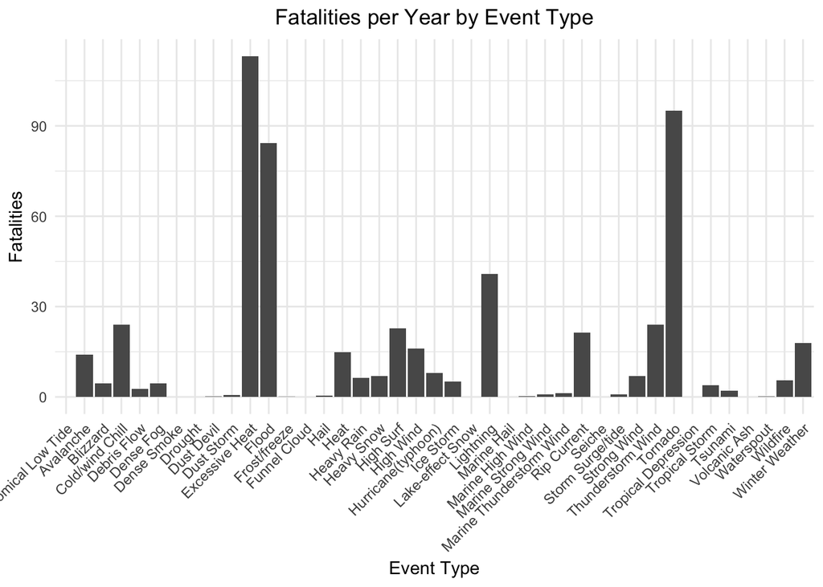

```r
timeframe <- as.numeric(difftime(max(stormdt$bgn_date),
                                 min(stormdt$bgn_date),
                                 units = "days") / 365.25)

event_fatalities <- stormdt %>%
        group_by(evtype) %>%
        summarise(totalfatalities = sum(fatalities),
                  peryear = totalfatalities / timeframe,
                  occurences = n(),
                  fatalitiesperoccurence = totalfatalities / n()) %>%
        arrange(desc(totalfatalities))

ggplot(event_fatalities, aes(evtype, peryear)) +
        geom_bar(stat = "sum") +
        labs(title = "Fatalities per Year by Event Type",
             x = "Event Type", y = "Fatalities") +
        theme_minimal() +
        theme(axis.text.x = element_text(angle = 45, hjust = 1),
              plot.title = element_text(hjust = 0.5),
              legend.position = "none")
```

Table below expands on the data visualized above:

```r
knitr::kable(head(event_fatalities, n=10),
             caption = "Total Fatalities by Event",
             col.names = c("Event", "Total Fatalities",
                           "Fatalities per Year", "Occurences (since 1996)",
                           "Fatalities per Occurence"))
```

Total Fatalities by Event

| Event | Total Fatalities | Fatalities per Year | Occurences (since 1996) | Fatalities per Occurence |
| --- | --- | --- | --- | --- |
| Excessive Heat | 1800 | 113.13887 | 693 | 2.5974026 |
| Tornado | 1511 | 94.97380 | 12365 | 0.1221998 |
| Flood | 1340 | 84.22561 | 29527 | 0.0453822 |
| Lightning | 650 | 40.85570 | 11151 | 0.0582907 |
| Thunderstorm Wind | 383 | 24.07344 | 105453 | 0.0036319 |
| Cold/wind Chill | 382 | 24.01058 | 420 | 0.9095238 |
| High Surf | 361 | 22.69063 | 475 | 0.7600000 |
| Rip Current | 340 | 21.37068 | 364 | 0.9340659 |
| Winter Weather | 285 | 17.91366 | 2215 | 0.1286682 |
| High Wind | 254 | 15.96515 | 5476 | 0.0463842 |

```r
event_fatalities <- stormdt %>%
        group_by(evtype) %>%
        summarise(totalfatalities = sum(fatalities),
                  peryear = totalfatalities / timeframe,
                  occurences = n(),
                  fatalitiesperoccurence = totalfatalities / n()) %>%
        arrange(desc(fatalitiesperoccurence))

knitr::kable(head(event_fatalities, n=7),
             caption = "Total Fatalities by Event",
             col.names = c("Event", "Total Fatalities",
                           "Fatalities per Year", "Occurences (since 1996)",
                           "Fatalities per Occurence"))
```

Total Fatalities by Event

| Event | Total Fatalities | Fatalities per Year | Occurences (since 1996) | Fatalities per Occurence |
| --- | --- | --- | --- | --- |
| Excessive Heat | 1800 | 113.138875 | 693 | 2.5974026 |
| Tsunami | 33 | 2.074213 | 14 | 2.3571429 |
| Heat | 237 | 14.896619 | 165 | 1.4363636 |
| Rip Current | 340 | 21.370676 | 364 | 0.9340659 |
| Cold/wind Chill | 382 | 24.010583 | 420 | 0.9095238 |
| Avalanche | 223 | 14.016649 | 264 | 0.8446970 |
| High Surf | 361 | 22.690630 | 475 | 0.7600000 |

By the visualization and table above, the 3 event types which have the greatest impact of mortality are: Excessive Heat, Tornado, and Flood. The impact of these events will be further examined.

##### PublicHealth 1)Excessive Heat

- most impacted states
- count by month

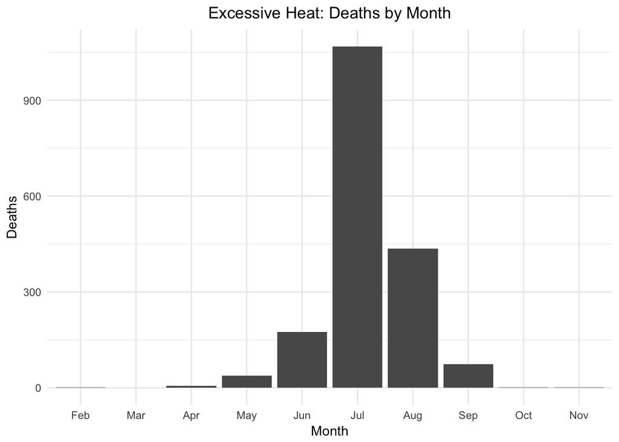

```r
excessive_heat <- stormdt[which(stormdt$evtype == "Excessive Heat"),]

excessive_heat_vis <- excessive_heat %>%
        mutate(month = format(bgn_datetime, "%m")) %>%
        group_by(month) %>%
        summarise(totalfatalities = sum(fatalities))

# excessive_heat_vis$month <- month.abb[as.numeric(excessive_heat_vis$month)]

ggplot(excessive_heat_vis,aes(month, totalfatalities),
       color = aes(time_zone)) +
        geom_col() +
        labs(title = "Excessive Heat: Deaths by Month",
             x = "Month", y = "Deaths") +
        scale_x_discrete(labels = month.abb[as.numeric(
                                  excessive_heat_vis$month)]) +
        theme_minimal() +
        theme(plot.title = element_text(hjust = 0.5))
```

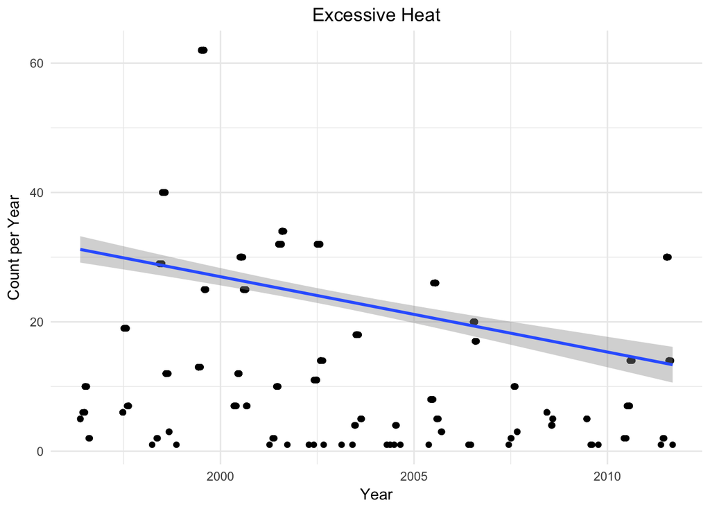

```r
excessive_heat_count <- excessive_heat %>%
        mutate(month = format(bgn_datetime, "%m")) %>%
        group_by(adjyear, month) %>%
        mutate(count = n())

ggplot(excessive_heat_count, aes(bgn_datetime, count)) +
        geom_point() +
        geom_smooth(method = lm) +
        labs(title = "Excessive Heat",
             x = "Year", y = "Count per Year") +
        theme_minimal() +
        theme(plot.title = element_text(hjust = .5))
```

##### Public Health 2)Tornado

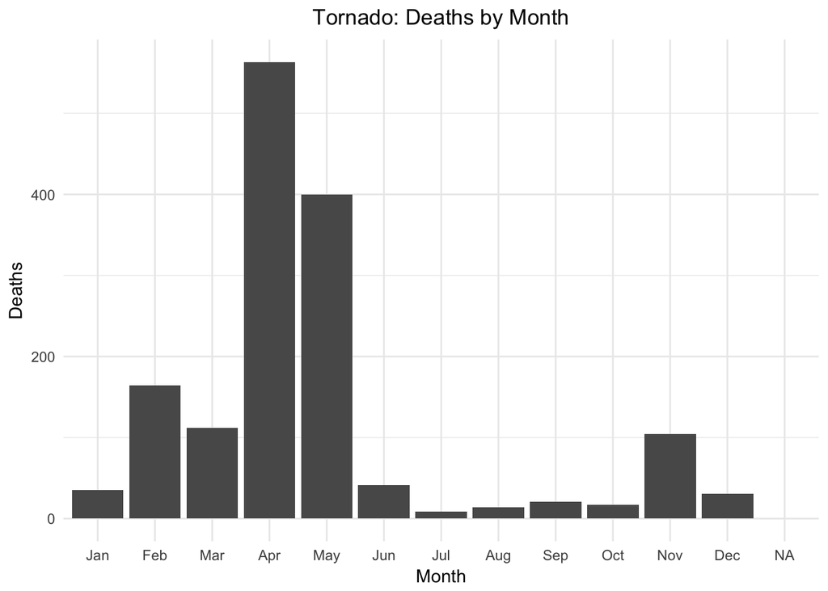

```r
tornado <- stormdt[which(stormdt$evtype == "Tornado"),]

tornado_vis <-
        tornado %>%
        mutate(month = format(bgn_datetime, "%m")) %>%
        group_by(month) %>%
        summarise(monthfatalities = sum(fatalities))

ggplot(tornado_vis,aes(month, monthfatalities)) +
        geom_col() +
        labs(title = "Tornado: Deaths by Month",
             x = "Month", y = "Deaths") +
        scale_x_discrete(labels = month.abb[as.numeric(tornado_vis$month)]) +
        theme_minimal() +
        theme(plot.title = element_text(hjust = 0.5))
```

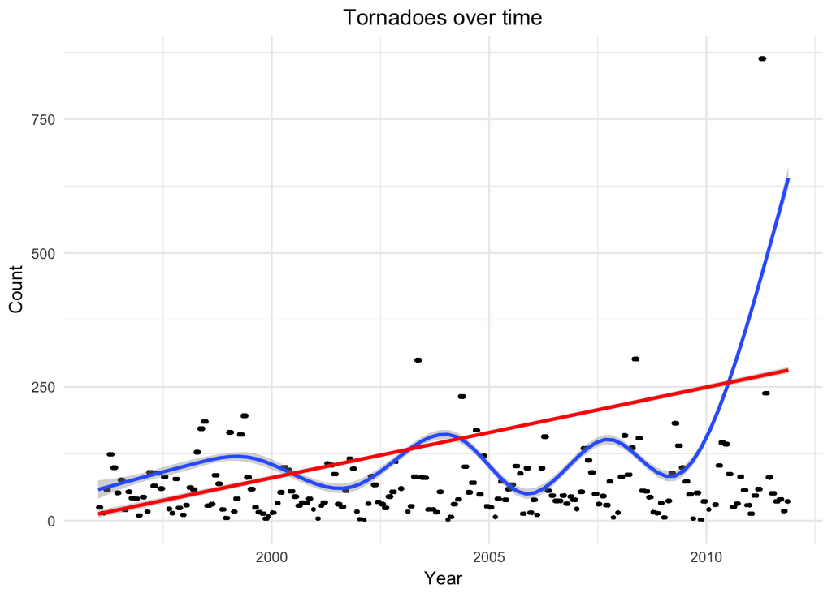

```r
tornado_counts <-
        tornado %>%
        group_by(format(bgn_datetime, "%Y%m")) %>%
        mutate(count = n())

ggplot(tornado_counts, aes(bgn_datetime, count)) +
        geom_point(size = .5) +
        geom_smooth() +
        geom_smooth(method = lm, color = "red") +
        labs(title = "Tornadoes over time",
             x = "Year", y = "Count") +
        theme_minimal() +
        theme(plot.title = element_text(hjust = .5))
```

```r
tornado_zone_stats <-
        tornado %>%
        group_by(time_zone) %>%
        summarise(count = n()) %>%
        arrange(desc(count))

knitr::kable(tornado_zone_stats, caption = "Torandos by Region",
             col.names = c("Region", "Tornados"))
```

Torandos by Region

| Region | Tornados |
| --- | --- |
| CST | 8048 |
| EST | 3833 |
| MST | 328 |
| PST | 145 |
| AST | 9 |
| HST | 2 |

[figure not shown]

```r
cst_tornado <- tornado[which(tornado$time_zone == "CST"),]

cst_tornado_counts <-
        cst_tornado %>%
        group_by(format(bgn_datetime, "%Y")) %>%
        mutate(count = n())

ggplot(tornado_counts, aes(bgn_datetime, count)) +
        geom_point() +
        geom_smooth(method = lm, color = "red") +
        geom_smooth() +
        labs(title = "Central Region Tornados",
             x = "Year", y = "Number of Tornados") +
        theme_minimal() +
        theme(plot.title = element_text(hjust = 0.5))
```

##### Flood

[figure not shown]

```r
flood <- stormdt[which(stormdt$evtype == "Flood"),]
flood_vis <- flood %>%
        mutate(month = format(bgn_datetime, "%m")) %>%
        group_by(month)


#Gotta fix the labeling issue
ggplot(flood_vis,aes(month)) +
        geom_bar() +
        labs(title = "Flood Frequency by Month",
             x = "Month", y = "Count") +
        scale_x_discrete(labels = month.abb[unique(as.numeric(flood_vis$month))]) +
        theme_minimal() +
        theme(plot.title = element_text(hjust = 0.5))
```

#### Examining Injuries by event type:

[figure not shown]

```r
event_injuries <- stormdt %>%
        group_by(evtype) %>%
        summarise(totalinjuries = sum(injuries),
                  injuryperyear = totalinjuries / timeframe,
                  injuryperoccurence = totalinjuries / n(),
                  occurences = n(),
                  occurencesperyear = occurences/timeframe) %>%
        arrange(desc(totalinjuries))

ggplot(event_injuries, aes(evtype, injuryperyear)) +
        geom_bar(stat = "sum") +
        labs(title = "Injuries by Event Type since 1996",
             x = "Event Type", y = "Total Injuries") +
        theme_minimal() +
        theme(axis.text.x = element_text(angle = 45, hjust = 1),
              plot.title = element_text(hjust = 0.5),
              legend.position = "none")
```

```r
knitr::kable(head(event_injuries), caption = "Total Injuries by Event since 1996",
             col.names = c("Event", "injuryperyear, Total Injuries",
                           "Injuries per Occurence", "Occurences",
                           "Occurences per Year"))
```

```
## Error in `colnames<-`(`*tmp*`, value = c("Event", "injuryperyear, Total Injuries", : length of 'dimnames' [2] not equal to array extent
```

[figure not shown]

```r
flood <- stormdt[which(stormdt$evtype == "Flood"),]
flood_vis <- flood %>%
        mutate(month = format(bgn_datetime, "%m")) %>%
        group_by(month) %>%
        mutate(count = n())

ggplot(flood_vis,aes(month)) +
        geom_bar() +
        labs(title = "Frequency of Floods by Month",
             x = "Month", y = "Count") +
        scale_x_discrete(labels = month.abb[unique(as.numeric(flood_vis$month))]) +
        theme_minimal() +
        theme(plot.title = element_text(hjust = .5))
```

#### Economic Impact

##### Property Damage

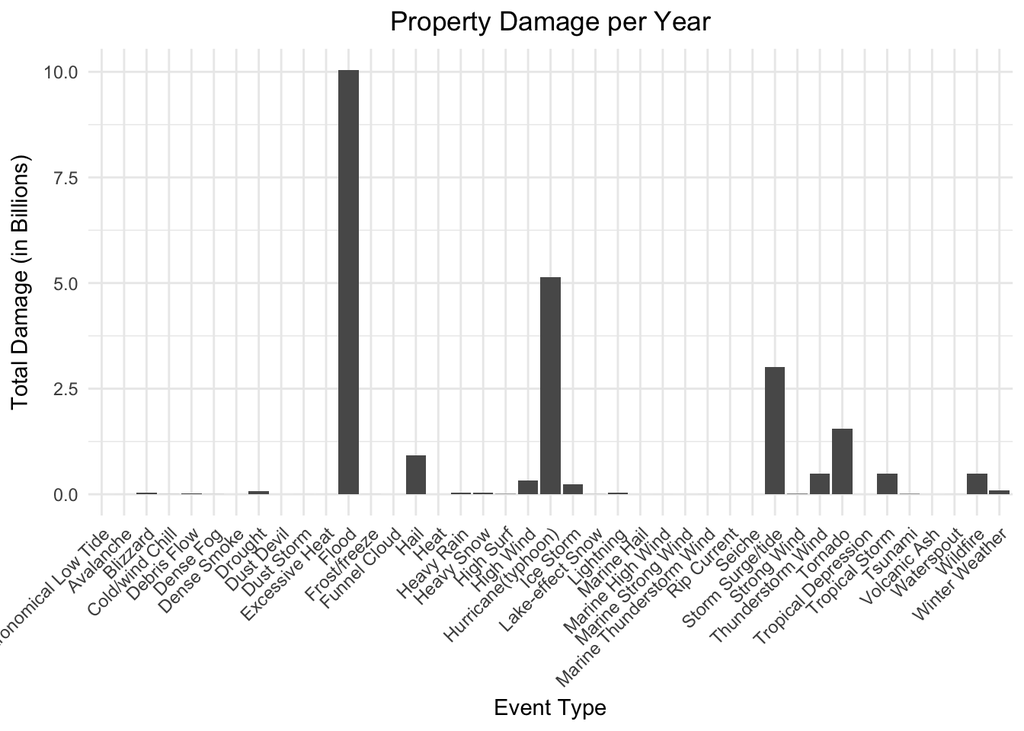

```r
event_propdmg <- stormdt %>%
        group_by(evtype) %>%
        summarise(totalpropdmg = sum(propdmg),
                  damageperyear = totalpropdmg / timeframe,
                  damageperoccurence = totalpropdmg / n(),
                  occurences = n(),
                  occurencesperyear = occurences/timeframe) %>%
        mutate(totalpropdmg = totalpropdmg / 1E9,
               damageperoccurence = damageperoccurence / 1E6,
               damageperyear = damageperyear / 1E9) %>%
        arrange(desc(damageperyear))

ggplot(event_propdmg, aes(evtype, damageperyear)) +
        geom_bar(stat = "sum") +
        labs(title = "Property Damage per Year",
             x = "Event Type", y = "Total Damage (in Billions)") +
        theme_minimal() +
        theme(axis.text.x = element_text(angle = 45, hjust = 1),
              plot.title = element_text(hjust = 0.5),
              legend.position = "none")
```

Table below expands upon property damage by event type

```r
knitr::kable(head(event_propdmg, n=10),
             caption = "Property Damage by Event since 1996",
             col.names = c("Event", "Damage (in Billions)", "Damage per Year",
                           "Average Damage (in Millions)","Occurences",
                           "Occurences per Year"))
```

Property Damage by Event since 1996

| Event | Damage (in Billions) | Damage per Year | Average Damage (in Millions) | Occurences | Occurences per Year |
| --- | --- | --- | --- | --- | --- |
| Flood | 159.774855 | 10.0426374 | 5.4111442 | 29527 | 1855.91753 |
| Hurricane(typhoon) | 81.718889 | 5.1364351 | 392.8792741 | 208 | 13.07383 |
| Storm Surge/tide | 47.834724 | 3.0066482 | 221.4570556 | 216 | 13.57666 |
| Tornado | 24.616906 | 1.5472939 | 1.9908537 | 12365 | 777.20121 |
| Hail | 14.595213 | 0.9173811 | 0.6432443 | 22690 | 1426.17837 |
| Thunderstorm Wind | 7.915343 | 0.4975183 | 0.0750604 | 105453 | 6628.24097 |
| Wildfire | 7.760450 | 0.4877825 | 6.3144422 | 1229 | 77.24871 |
| Tropical Storm | 7.642526 | 0.4803704 | 18.4157242 | 415 | 26.08480 |
| High Wind | 5.250713 | 0.3300332 | 0.9588592 | 5476 | 344.19360 |
| Ice Storm | 3.642249 | 0.2289333 | 5.7721851 | 631 | 39.66146 |

##### Flood

```r
flood <- stormdt[which(stormdt$evtype == "Flood"),]
flood_propdmg <-
        flood %>%
        mutate(month = format(bgn_datetime, "%m")) %>%
        group_by(month)
```

[figure not shown]

```r
ggplot(flood_vis,aes(month)) +
        geom_bar() +
        labs(title = "Frequency of Floods by Month",
             x = "Month", y = "Count") +
        scale_x_discrete(labels = month.abb[unique(as.numeric(flood_vis$month))]) +
        theme_minimal() +
        theme(plot.title = element_text(hjust = .5))
```

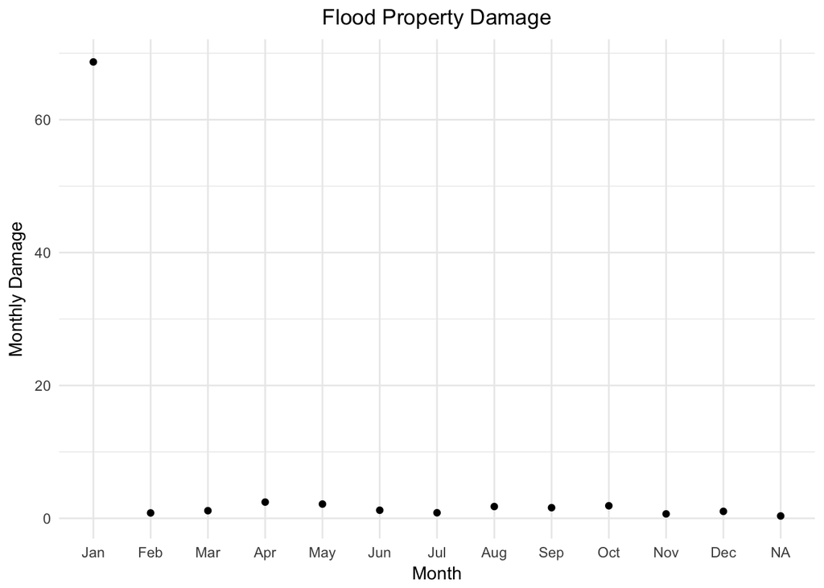

```r
flood_propdmg_avg <-
        flood_propdmg %>%
        summarise(monthlydmgavg = mean(propdmg)) %>%
        mutate(monthlydmgavg = monthlydmgavg / 1E6)

ggplot(flood_propdmg_avg, aes(month, monthlydmgavg)) +
        geom_point() +
        labs(title = "Flood Property Damage",
             x = "Month", y = "Monthly Damage") +
        theme_minimal() +
        theme(plot.title = element_text(hjust = .5)) +
        scale_x_discrete(labels = month.abb[as.numeric(flood_propdmg_avg$month)])
```

##### Crop Damage

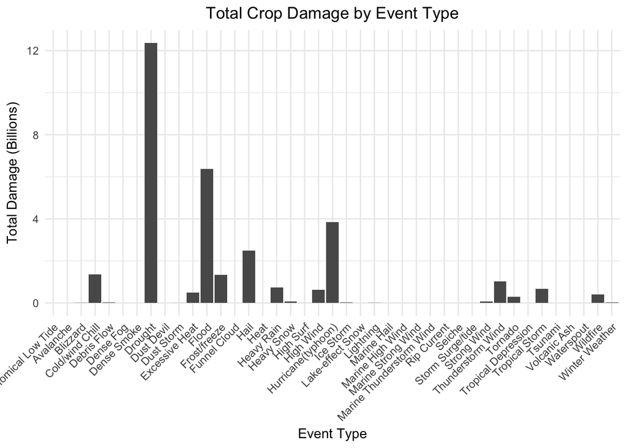

```r
event_cropdmg <- stormdt %>%
        group_by(evtype) %>%
        summarise(totalcropdmg = sum(cropdmg),
                  cropdmgperyear = totalcropdmg / timeframe,
                  cropdmgperoccurence = totalcropdmg/n(),
                  occurences = n(),
                  occurencesperyear = occurences / timeframe) %>%
        mutate(totalcropdmg = totalcropdmg / 1E9,
               cropdmgperoccurence = cropdmgperoccurence/1E6,
               cropdmgperyear = cropdmgperyear / 1E6) %>%
        arrange(desc(cropdmgperyear))

ggplot(event_cropdmg, aes(evtype, totalcropdmg), fill = evtype) +
        geom_bar(stat = "sum") +
        labs(title = "Total Crop Damage by Event Type",
             x = "Event Type", y = "Total Damage (Billions)") +
        theme_minimal() +
        theme(axis.text.x = element_text(angle = 45, hjust = 1),
              plot.title = element_text(hjust = 0.5),
              legend.position = "none")
```

Table below expands upon crop damage.

```r
knitr::kable(head(event_cropdmg, n=10), caption = "Crop Damage by Event",
             col.names = c("Event", "Total Damage (in Billions)",
                           "Damage per Year (Millions)",
                           "Damage per Occurence (in Millions)",
                           "Occurences", "Occurences per Year"))
```

Crop Damage by Event

| Event | Total Damage (in Billions) | Damage per Year (Millions) | Damage per Occurence (in Millions) | Occurences | Occurences per Year |
| --- | --- | --- | --- | --- | --- |
| Drought | 12.3675660 | 777.36250 | 47.9363023 | 258 | 16.216572 |
| Flood | 6.3821932 | 401.15231 | 0.2161477 | 29527 | 1855.917527 |
| Hurricane(typhoon) | 3.8401078 | 241.36971 | 18.4620567 | 208 | 13.073825 |
| Hail | 2.4968224 | 156.93760 | 0.1100407 | 22690 | 1426.178369 |
| Cold/wind Chill | 1.3567655 | 85.27940 | 3.2303940 | 420 | 26.399071 |
| Frost/freeze | 1.3346310 | 83.88814 | 9.7418321 | 137 | 8.611125 |
| Thunderstorm Wind | 1.0169576 | 63.92080 | 0.0096437 | 105453 | 6628.240965 |
| Heavy Rain | 0.7384198 | 46.41333 | 0.6799446 | 1086 | 68.260454 |
| Tropical Storm | 0.6777110 | 42.59748 | 1.6330386 | 415 | 26.084796 |
| High Wind | 0.6338613 | 39.84131 | 0.1157526 | 5476 | 344.193598 |